# Comparando mecanismos para jukebox sociais

```r
dados = read_csv(here::here("data/satisfacoes.csv"),
                 col_types = "cdcc")

dados = dados %>%
    filter(scenario != "like/dislike")

glimpse(dados)
```

```
## Rows: 92
## Columns: 4
## $ user_id      <chr> "1", "2", "3", "4", "5", "6", "7", "8", "9", "10", "11", …
## $ satisfaction <dbl> 2.0, 3.0, 1.5, 1.0, 2.0, 2.5, 2.0, 3.0, 2.0, 2.0, 2.0, 2.…
## $ scenario     <chr> "baseline", "baseline", "baseline", "baseline", "baseline…
## $ group        <chr> "3", "1", "2", "2", "1", "1", "3", "3", "2", "1", "3", "2…
```

```r
dados_wide = dados %>%
    pivot_wider(names_from = "scenario", values_from = satisfaction)

dados_wide = dados_wide %>%
    mutate(
        combined_baseline = combined - baseline,
        updown_baseline = `up/downvoting` - baseline,
        skip_baseline = skip - baseline,
        updown_combined = `up/downvoting` - combined,
        combined_skip = combined - skip,
        updown_skip = `up/downvoting` - skip
    )
```

```r
theta <- function(d, i) {
    d[i] %>%
        mean(na.rm = T)
}

theta(dados_wide$combined_baseline, 1:NROW(dados_wide))
```

```
## [1] 1.95
```

```r
theta(dados_wide$updown_baseline, 1:NROW(dados_wide))
```

```
## [1] 2.25
```

```r
THETA_A = theta(dados$satisfaction, 1:NROW(dados))

THETA_A
```

```
## [1] 3.271739
```

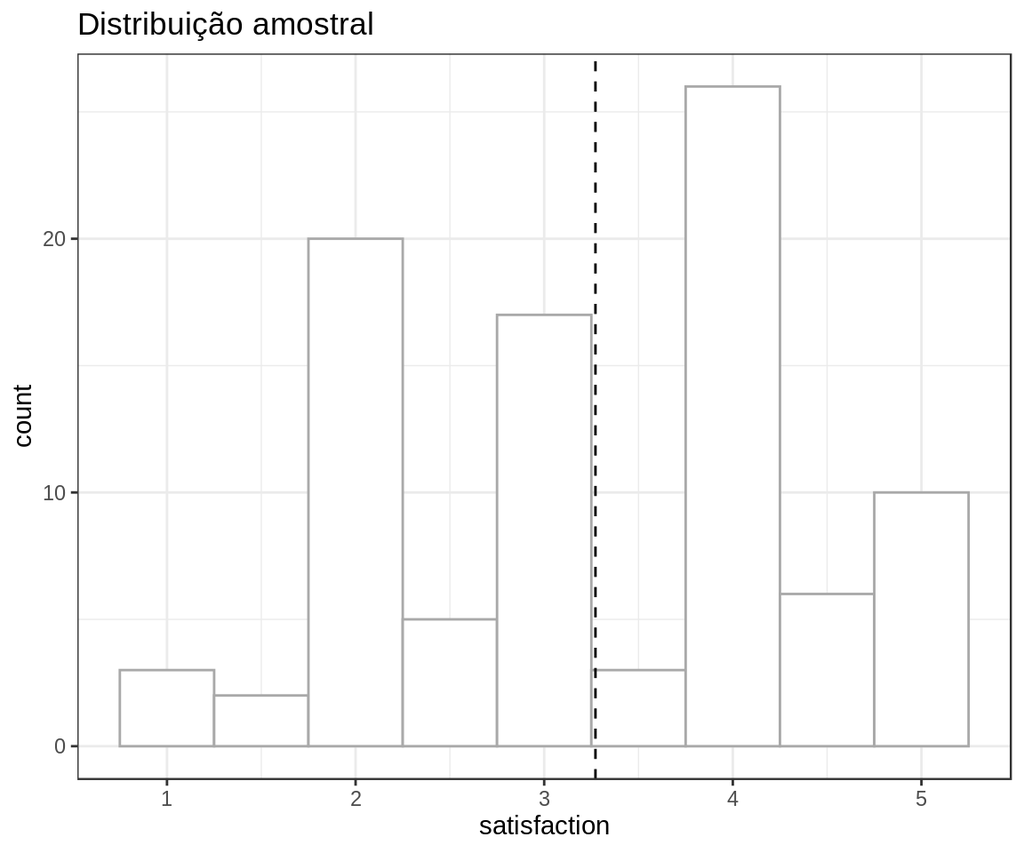

```r
dados %>%
  ggplot(aes(satisfaction)) +
  geom_histogram(binwidth = .5,
                 fill = "white",
                 colour = "darkgrey") +
  geom_vline(xintercept = THETA_A, linetype = "dashed") +
  labs(title = "Distribuição amostral")
```

```r
ci_combined = boot(data = dados_wide$combined_baseline,
                   statistic = theta,
                   R = 2000) %>%
    tidy(conf.level = .95,
         conf.method = "bca",
         conf.int = TRUE)

ci_combined
```

```
## # A tibble: 1 x 5
##   statistic     bias std.error conf.low conf.high
##       <dbl>    <dbl>     <dbl>    <dbl>     <dbl>
## 1      1.95 -0.00290     0.218     1.58      2.41
```

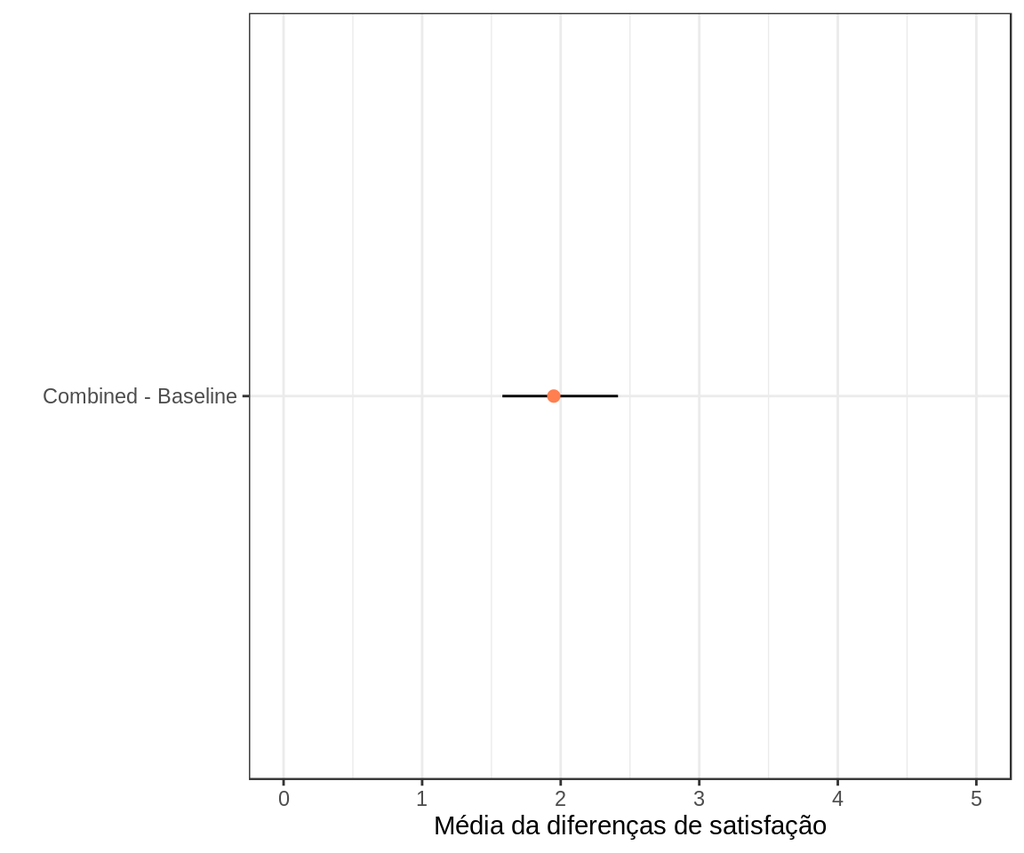

```r
ci_combined %>%
  ggplot(aes(
            ymin = conf.low,
            y = statistic,
            ymax = conf.high,
            x = "Combined - Baseline"
        )) +
        geom_linerange() +
        geom_point(color = "coral", size = 2) +
        scale_y_continuous(limits = c(0, 5)) +
        labs(x = "", y = "Média da diferenças de satisfação") +
        coord_flip()
```

No intervalo de 95% de confiança a estratégia Combined tem maior satisfação do que a estratégia Baseline, com uma diferença média de 2 pontos e com um margem de erro de 0.5 para mais ou para menos.

```r
ci_skip = boot(data = dados_wide$skip_baseline,
                   statistic = theta,
                   R = 2000) %>%
    tidy(conf.level = .99,
         conf.method = "bca",
         conf.int = TRUE)

ci_skip
```

```
## # A tibble: 1 x 5
##   statistic     bias std.error conf.low conf.high
##       <dbl>    <dbl>     <dbl>    <dbl>     <dbl>
## 1     0.425 -0.00472     0.129   0.0367     0.726
```

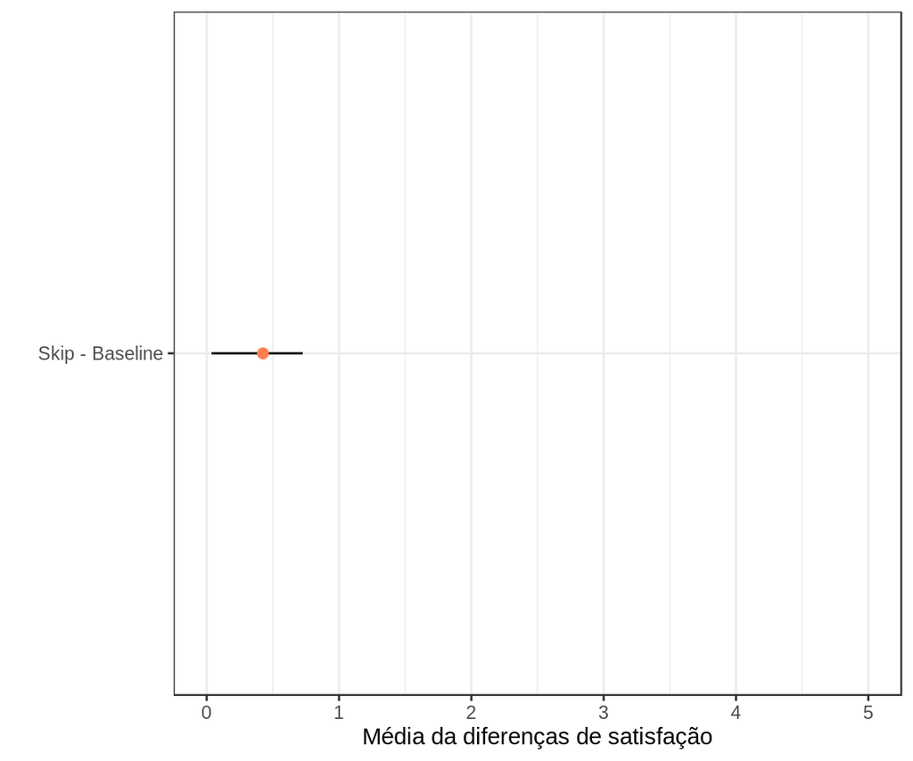

```r
ci_skip %>%
  ggplot(aes(
            ymin = conf.low,
            y = statistic,
            ymax = conf.high,
            x = "Skip - Baseline"
        )) +
        geom_linerange() +
        geom_point(color = "coral", size = 2) +
        scale_y_continuous(limits = c(0, 5)) +
        labs(x = "", y = "Média da diferenças de satisfação") +
        coord_flip()
```

Num intervalo de 99% de confiança a estratégia Skip tem chance de ter maior satisfação em relação à estratégia Baseline, com uma diferença média de aproximadament 0.4 e uma margem de erro de aproximadamente 0.3 para mais ou 0.4 para menos, havendo a possibilidade de não a diferença entre as duas não existir.

```r
ci_updown = boot(data = dados_wide$updown_baseline,
                   statistic = theta,
                   R = 2000) %>%
    tidy(conf.level = .95,
         conf.method = "bca",
         conf.int = TRUE)

ci_updown
```

```
## # A tibble: 1 x 5
##   statistic    bias std.error conf.low conf.high
##       <dbl>   <dbl>     <dbl>    <dbl>     <dbl>
## 1      2.25 0.00291     0.181     1.89      2.58
```

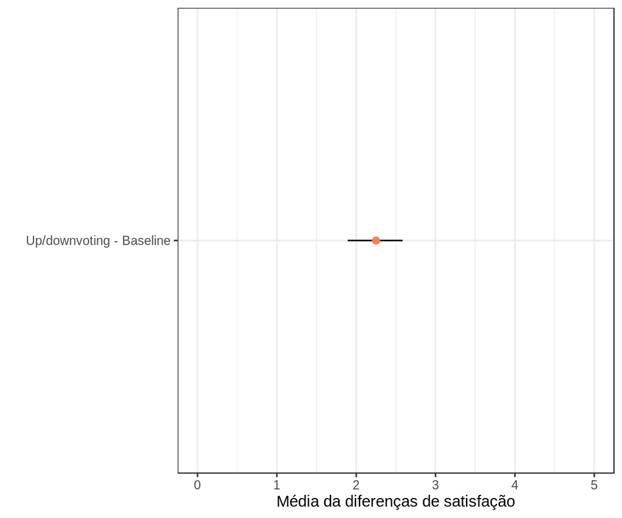

```r
ci_updown %>%
  ggplot(aes(
            ymin = conf.low,
            y = statistic,
            ymax = conf.high,
            x = "Up/downvoting - Baseline"
        )) +
        geom_linerange() +
        geom_point(color = "coral", size = 2) +
        scale_y_continuous(limits = c(0, 5)) +
        labs(x = "", y = "Média da diferenças de satisfação") +
        coord_flip()
```

Num intervalo de 95% de confiança a estratégia Up/downvotings tem maior satisfação em relação à estratégia Baseline, com uma diferença média de 2.3 e com um margem de erro de aproximadamente 0.3 para mais ou para menos.

Analisando a comparação das outras estratégias com a Baseline, a Up/downvotings parece ser a que mais leva vantagem, pois possui a maior diferença e uma margem de erro pequena.

```r
ci_updown_combined = boot(data = dados_wide$updown_combined,
                   statistic = theta,
                   R = 2000) %>%
    tidy(conf.level = .95,
         conf.method = "bca",
         conf.int = TRUE)

ci_updown_combined
```

```
## # A tibble: 1 x 5
##   statistic    bias std.error conf.low conf.high
##       <dbl>   <dbl>     <dbl>    <dbl>     <dbl>
## 1     0.348 0.00489     0.156   0.0227     0.646
```

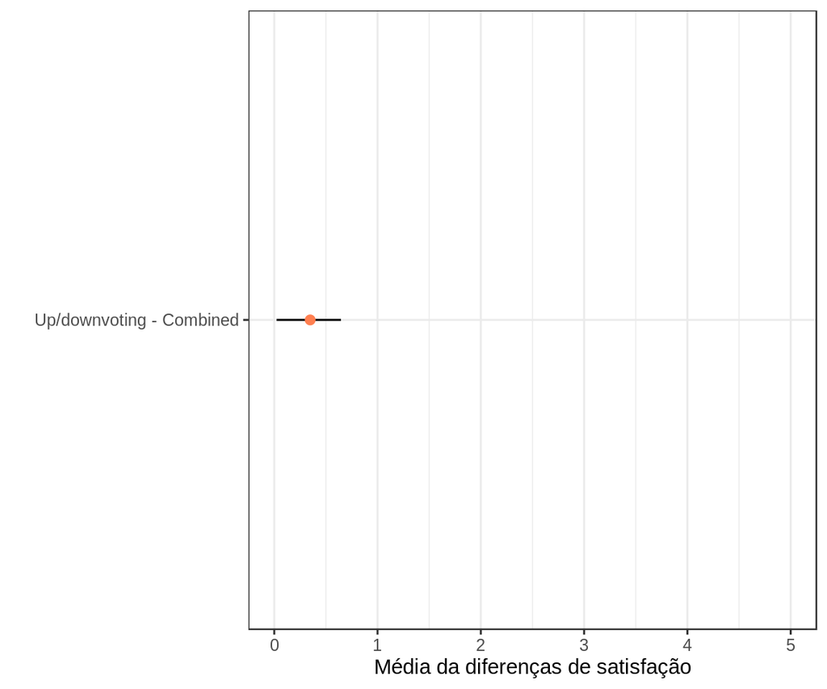

```r
ci_updown_combined %>%
  ggplot(aes(
            ymin = conf.low,
            y = statistic,
            ymax = conf.high,
            x = "Up/downvoting - Combined"
        )) +
        geom_linerange() +
        geom_point(color = "coral", size = 2) +
        scale_y_continuous(limits = c(0, 5)) +
        labs(x = "", y = "Média da diferenças de satisfação") +
        coord_flip()
```

Num intervalo de 95% de confiança a estratégia Up/downvotings parece ter maior satisfação em relação à estratégia Combined, com uma diferença média de 0.4 e com um margem de erro de aproximadamente 0.4 para mais ou para menos, podendo não haver nenhuma diferença de satisfação entre elas.

```r
ci_skip_combined = boot(data = dados_wide$combined_skip,
                   statistic = theta,
                   R = 2000) %>%
    tidy(conf.level = .95,
         conf.method = "bca",
         conf.int = TRUE)

ci_skip_combined
```

```
## # A tibble: 1 x 5
##   statistic     bias std.error conf.low conf.high
##       <dbl>    <dbl>     <dbl>    <dbl>     <dbl>
## 1      1.52 -0.00643     0.175      1.2      1.89
```

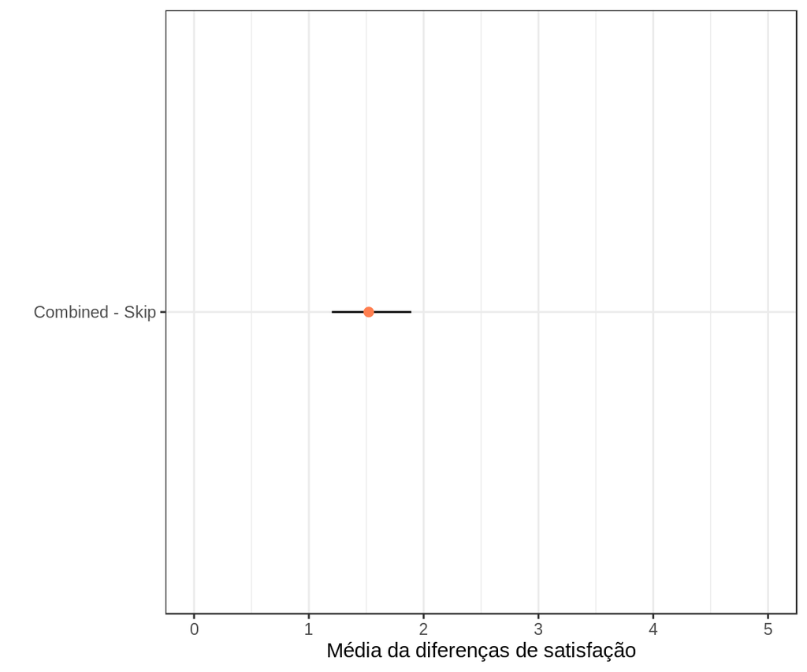

```r
ci_skip_combined %>%
  ggplot(aes(
            ymin = conf.low,
            y = statistic,
            ymax = conf.high,
            x = "Combined - Skip"
        )) +
        geom_linerange() +
        geom_point(color = "coral", size = 2) +
        scale_y_continuous(limits = c(0, 5)) +
        labs(x = "", y = "Média da diferenças de satisfação") +
        coord_flip()
```

Num intervalo de 95% de confiança a estratégia Combined tem maior satisfação em relação à estratégia Skip, com uma diferença média de 1.5 e com um margem de erro de aproximadamente 0.4 para mais ou 0.3 para menos.

```r
ci_skip_updown = boot(data = dados_wide$updown_skip,
                   statistic = theta,
                   R = 2000) %>%
    tidy(conf.level = .95,
         conf.method = "bca",
         conf.int = TRUE)

ci_skip_updown
```

```
## # A tibble: 1 x 5
##   statistic    bias std.error conf.low conf.high
##       <dbl>   <dbl>     <dbl>    <dbl>     <dbl>
## 1      1.87 0.00133     0.138     1.59      2.14
```

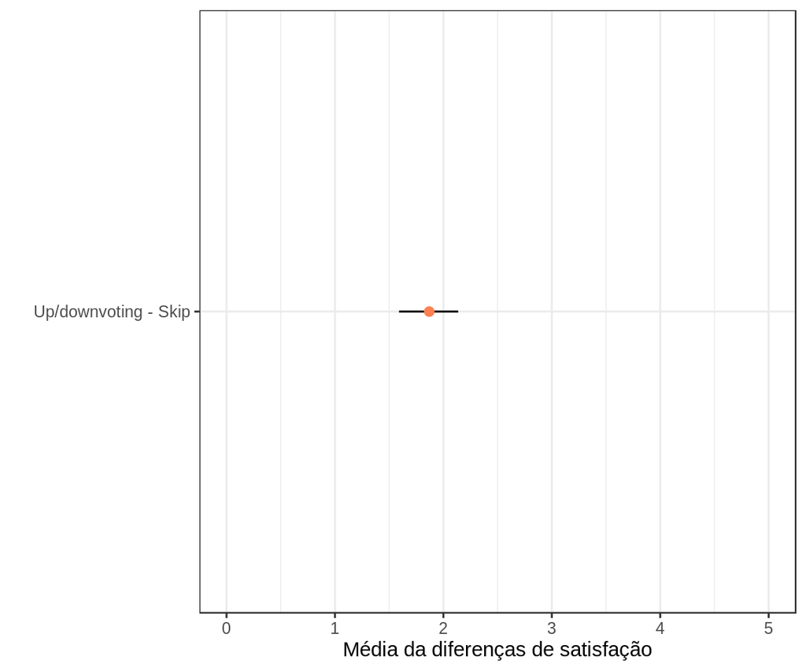

```r
ci_skip_updown %>%
  ggplot(aes(
            ymin = conf.low,
            y = statistic,
            ymax = conf.high,
            x = "Up/downvoting - Skip"
        )) +
        geom_linerange() +
        geom_point(color = "coral", size = 2) +
        scale_y_continuous(limits = c(0, 5)) +
        labs(x = "", y = "Média da diferenças de satisfação") +
        coord_flip()
```

Através das análises feitas podemos concluir que no geral a estrátégia Up/downvoting traz melhores resultados, mas se não for possível implementá-la, a estratégia Combined é uma boa opção, trazendo um nível de satisfação melhor que a Baseline e a Skip.